# EAS509_Project2

Vinitha Vudhayagiri

2023-05-05

##### Libraries used are

```r
library(forecast)
library(tseries)
library(zoo)
library(knitr)
```

#### **1. Reading the CSV data file**

```r
oil_data <- read.csv("/Users/vinithavudhayagiri/Documents/Spring2023/SDM2/Project2/oil.csv")
# Check the dimensions of the data frame
dim(oil_data)
```

```
## [1] 1218    2
```

```r
# printing the first few rows of the data
head(oil_data)
```

```
##         date dcoilwtico
## 1 2013-01-01         NA
## 2 2013-01-02      93.14
## 3 2013-01-03      92.97
## 4 2013-01-04      93.12
## 5 2013-01-07      93.20
## 6 2013-01-08      93.21
```

#### **2.Plotting the Time Series for the accessed data**

```r
# formatting the date column
oil_data$date <- as.Date(oil_data$date)
```

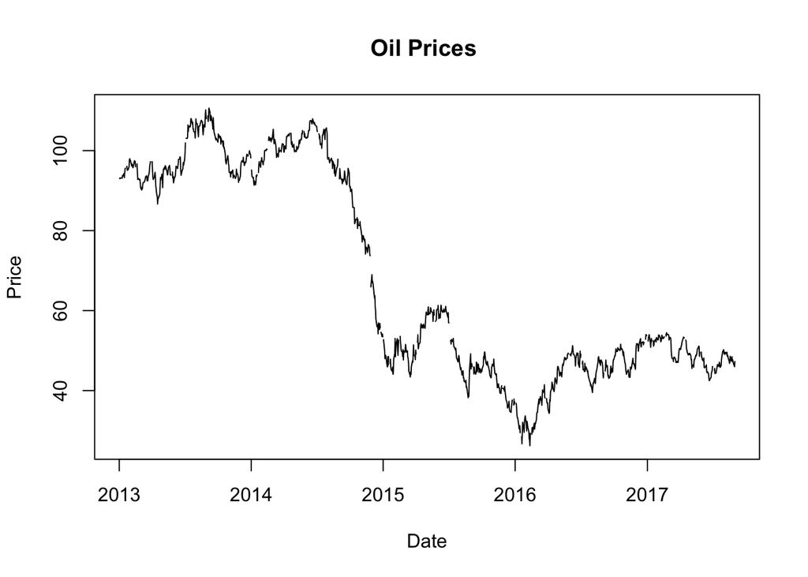

```r
plot(oil_data,ylab='Price',xlab='Date',type='l')
title("Oil Prices ")
```

From the above plot we can find that there is some discontinuity in the graph, as there are some missing values in the dataset there is cut at that slot in the graph. So, we have to replace the Null values for getting continuous plot for further analysis.

#### **3.Finding the missing values and imputing the data.**

```r
# checking if there are any null values
sum(is.na(oil_data))
```

```
## [1] 43
```

```r
# filling the data with the previous observation
oil_data$dcoilwtico = na.locf(oil_data$dcoilwtico, fromLast = TRUE)
# checking for the null values again to confirm if the data is being filled
sum(is.na(oil_data))
```

```
## [1] 0
```

There are 43 missing values in the dataset. We can use one of five methods to impute the data: forward fill, backward fill, mean imputation, linear interpolation, or seasonal interpolation. We selected backward fill because the prices are almost nearly equal for 5 to 7 days and the mean of the total series is far different from the values in the surrounding of the missing point.

#### **4.Plotting the time series for the updated data(without any missing data)**

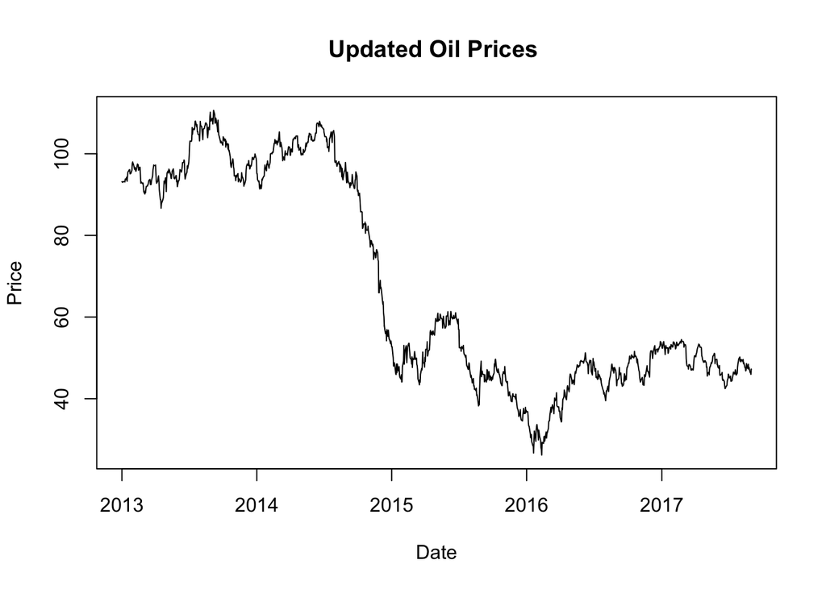

```r
plot(oil_data,ylab='Price',xlab='Date',type='l')
title("Updated Oil Prices ")
```

#### **5. Performing ETS Models and Holt-Winters Models**

```r
# Creating the time series object for the oil_data
oil_ts <- ts(oil_data$dcoilwtico, start = c(1986, 1), frequency = 12)
# Printing the time series object we created
oil_ts
```

```
##         Jan    Feb    Mar    Apr    May    Jun    Jul    Aug    Sep    Oct
## 1986  93.14  93.14  92.97  93.12  93.20  93.21  93.08  93.81  93.60  94.27
## 1987  95.49  95.61  96.09  96.09  95.06  95.35  95.15  95.95  97.62  97.98
## 1988  96.21  96.68  96.44  95.84  95.71  97.01  97.48  97.03  97.30  95.95
## 1989  94.92  92.79  93.12  92.74  92.63  92.84  92.03  90.71  90.13  90.88
## 1990  92.01  92.07  92.44  92.47  93.03  93.49  93.71  92.44  93.21  92.46
## 1991  95.99  96.53  97.24  97.10  97.10  97.23  95.02  93.26  92.76  93.36
## 1992  93.44  91.23  88.75  88.73  86.65  87.83  88.04  88.81  89.21  91.07
## 1993  94.09  93.22  90.74  93.70  95.25  95.80  95.28  96.24  96.09  95.81
## 1994  93.95  94.85  95.72  96.29  95.55  93.98  94.12  93.84  94.65  94.65
## 1995  91.93  93.41  93.36  93.66  94.71  96.11  95.82  95.50  95.98  96.66
## 1996  98.46  98.24  94.89  93.81  95.07  95.25  95.47  97.00  96.36  97.94
## 1997 103.09 103.09 103.03 103.46 106.41 104.77 105.85 106.20 105.88 106.39
## 1998 106.61 107.13 105.41 105.47 104.76 104.61 103.14 105.10 107.93 106.94
## 1999 104.41 103.45 106.04 106.19 106.78 106.89 107.43 107.58 107.14 104.90
```

[output cut: 191 more lines]

```r
# Perform the ADF test for stationarity
adf_test <- adf.test(oil_ts)

# Print the results
cat("ADF Statistic:", adf_test$statistic, "\n")
```

```
## ADF Statistic: -1.477923
```

```r
cat("p-value:", adf_test$p.value, "\n")
```

```
## p-value: 0.7993147
```

```r
cat("Critical values:", adf_test$critical, "\n")
```

```
## Critical values:
```

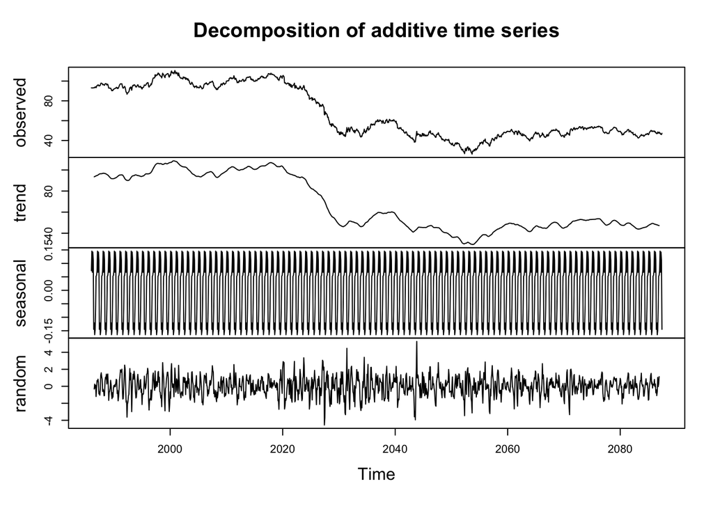

```r
# Decomposing the time series object to different components
components_oil_data <- decompose(oil_ts)
# Plotting the decomposed time series object
plot(components_oil_data)
```

#### **ETS Models**

ETS models are a family of time series forecasting methods that decompose a time series into three components: level, trend, and seasonality. It stands for Exponential Smoothing Time Series Analysis. It is a forecasting technique that uses weighted averages of past data to predict future values. It is a popular forecasting method because it is relatively easy to understand and implement.

ETS models are typically used to forecast time series that do not have a lot of noise. They are also a good choice for forecasting time series that have trend and seasonality components.

There are three main types of ETS models:

Additive ETS (AETS): This model assumes that the trend and seasonality components are additive, meaning that they can be added together to get the overall time series. Multiplicative ETS (METS): This model assumes that the trend and seasonality components are multiplicative, meaning that they are multiplied together to get the overall time series. Damped ETS (DETS): This model assumes that the trend component is damped, meaning that it will eventually level off. ETS models are relatively easy to understand and implement. They can be used to forecast a variety of time series, including those with trend, seasonality, or both. They are relatively accurate, especially for short-term forecasts. However, they can be sensitive to outliers. They can also be computationally expensive for large datasets. They may not be as accurate for long-term forecasts.

Overall, ETS models are a powerful tool for time series forecasting. They are relatively easy to understand and implement. They can be used to forecast a variety of time series, including those with trend, seasonality, or both.

#### **1.ETS ANN Model**

```r
# Split the data into train and test sets
train <- oil_ts[1:1000]
test <- oil_ts[1001:1218]

# Fit a ETS model to the training data
ets_model1 <- ets(train)

# Make a forecast for the test data
forecast <- forecast(ets_model1, h = length(test))

# Calculate accuracy measures
accuracy(forecast, test)
```

```
##                       ME     RMSE       MAE        MPE     MAPE     MASE
## Training set -0.04897223 1.263731 0.9540833 -0.1006894 1.606762 1.000902
## Test set      2.24778957 3.852265 3.1645261  4.1785992 6.237756 3.319816
##                       ACF1
## Training set -0.0009622352
## Test set                NA
```

```r
summary(ets_model1)
```

```
## ETS(A,N,N)
##
## Call:
##  ets(y = train)
##
##   Smoothing parameters:
##     alpha = 0.9433
##
##   Initial states:
##     l = 93.1343
##
##   sigma:  1.265
##
##      AIC     AICc      BIC
## 7381.893 7381.917 7396.616
##
## Training set error measures:
##                       ME     RMSE       MAE        MPE     MAPE     MASE
## Training set -0.04897223 1.263731 0.9540833 -0.1006894 1.606762 1.000902
##                       ACF1
## Training set -0.0009622352
```

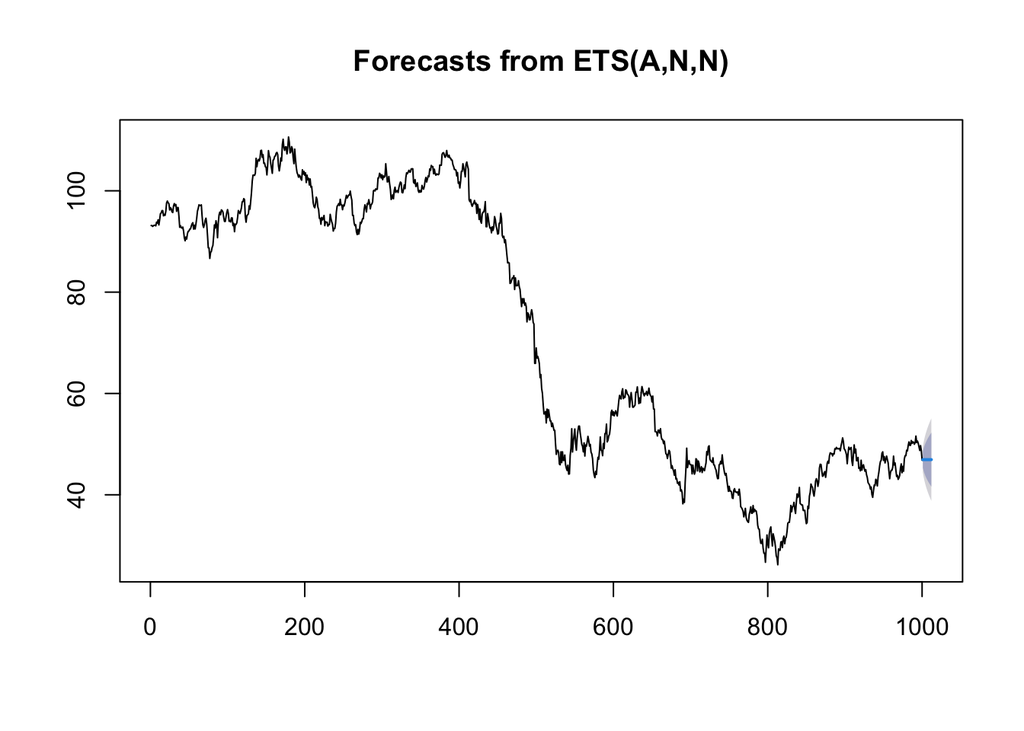

```r
# Make a forecast for the next 12 time periods
forecast <- forecast(ets_model1, h = 12)

# Plot the forecast and the actual data
plot(forecast)
lines(oil_ts, col = "blue")
```

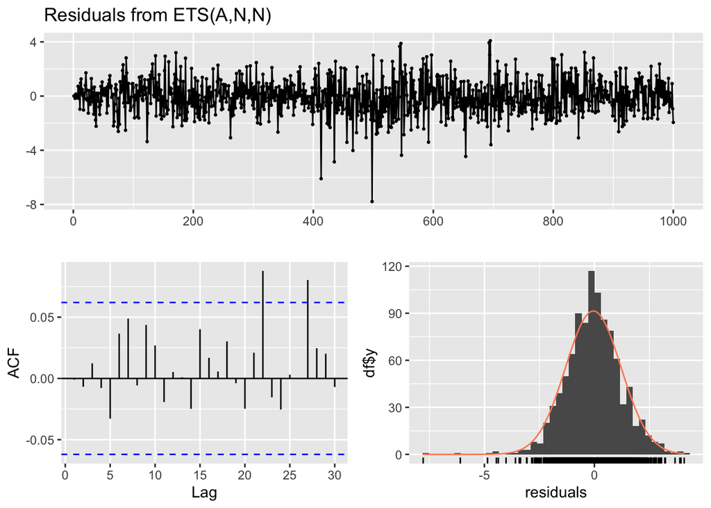

```
##
##  Ljung-Box test
##
## data:  Residuals from ETS(A,N,N)
## Q* = 7.7922, df = 10, p-value = 0.6491
##
## Model df: 0.   Total lags used: 10
```

```r
checkresiduals(ets_model1)
```

#### **2.ETS MNN Model**

```r
# Fit a Holt-Winters model to the training data
ets_model2 <- ets(train, model = "MNN")

# Make a forecast for the test data
forecast <- forecast(ets_model2, h = length(test))

# Calculate accuracy measures
accuracy(forecast, test)
```

```
##                       ME     RMSE       MAE       MPE     MAPE     MASE
## Training set -0.04932741 1.263772 0.9545491 -0.101423 1.607568 1.001391
## Test set      2.23223213 3.843208 3.1575323  4.146841 6.224924 3.312479
##                    ACF1
## Training set 0.00675492
## Test set             NA
```

```r
summary(ets_model2)
```

```
## ETS(M,N,N)
##
## Call:
##  ets(y = train, model = "MNN")
##
##   Smoothing parameters:
##     alpha = 0.9355
##
##   Initial states:
##     l = 93.1012
##
##   sigma:  0.0231
##
##      AIC     AICc      BIC
## 7772.955 7772.979 7787.678
##
## Training set error measures:
##                       ME     RMSE       MAE       MPE     MAPE     MASE
## Training set -0.04932741 1.263772 0.9545491 -0.101423 1.607568 1.001391
##                    ACF1
## Training set 0.00675492
```

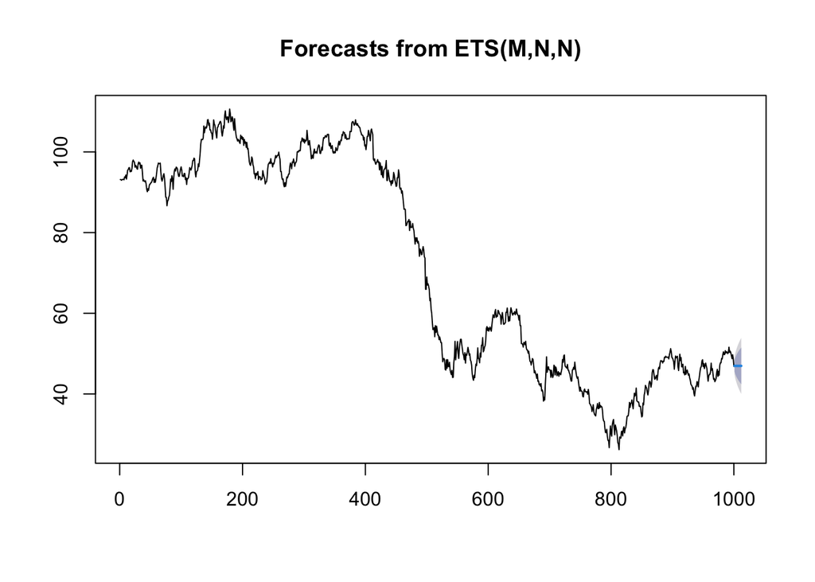

```r
# Make a forecast for the next 12 time periods
forecast <- forecast(ets_model2, h = 12)

# Plot the forecast and the actual data
plot(forecast)
lines(oil_ts, col = "blue")
```

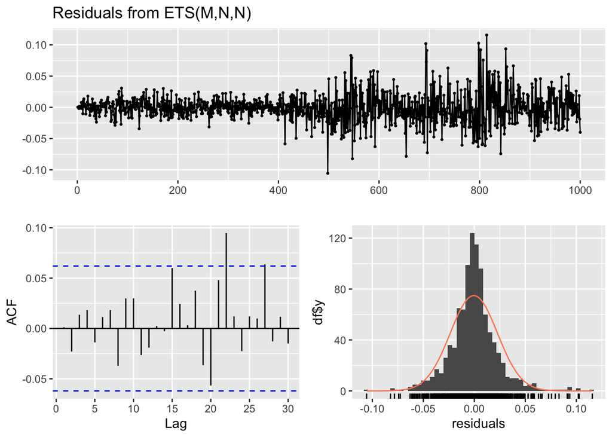

```
##
##  Ljung-Box test
##
## data:  Residuals from ETS(M,N,N)
## Q* = 4.9109, df = 10, p-value = 0.897
##
## Model df: 0.   Total lags used: 10
```

```r
checkresiduals(ets_model2)
```

#### **3.ETS MMN Model**

```r
# Fit a Holt-Winters model to the training data
ets_model3 <- ets(train, model = "MMN")

# Make a forecast for the test data
forecast <- forecast(ets_model3, h = length(test))

# Calculate accuracy measures
accuracy(forecast, test)
```

```
##                       ME     RMSE       MAE         MPE     MAPE     MASE
## Training set -0.01419079 1.262811 0.9543863 -0.05161738 1.605421 1.001220
## Test set      4.50849009 5.371351 4.7896028  8.85207454 9.485334 5.024639
##                    ACF1
## Training set 0.00759607
## Test set             NA
```

```r
summary(ets_model3)
```

```
## ETS(M,M,N)
##
## Call:
##  ets(y = train, model = "MMN")
##
##   Smoothing parameters:
##     alpha = 0.9347
##     beta  = 1e-04
##
##   Initial states:
##     l = 92.7668
##     b = 0.9995
##
##   sigma:  0.0232
##
##      AIC     AICc      BIC
## 7776.704 7776.764 7801.242
##
## Training set error measures:
##                       ME     RMSE       MAE         MPE     MAPE    MASE
## Training set -0.01419079 1.262811 0.9543863 -0.05161738 1.605421 1.00122
##                    ACF1
## Training set 0.00759607
```

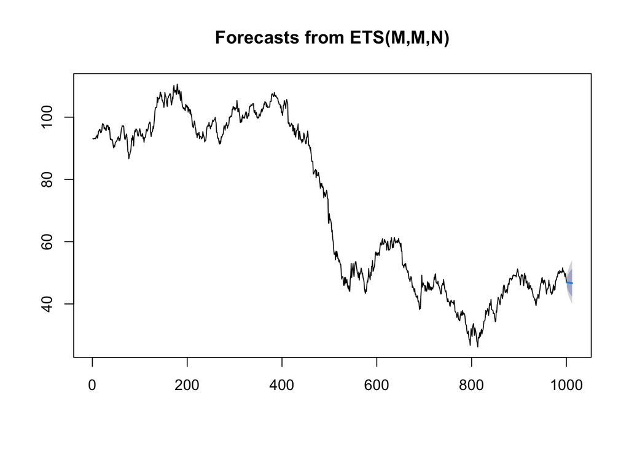

```r
# Make a forecast for the next 12 time periods
forecast <- forecast(ets_model3, h = 12)

# Plot the forecast and the actual data
plot(forecast)
lines(oil_ts, col = "blue")
```

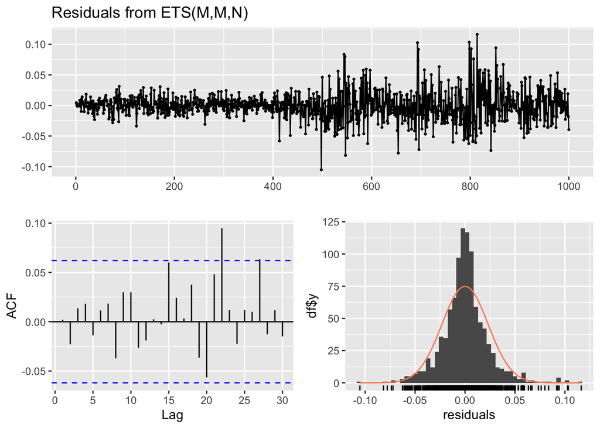

```
##
##  Ljung-Box test
##
## data:  Residuals from ETS(M,M,N)
## Q* = 4.9087, df = 10, p-value = 0.8972
##
## Model df: 0.   Total lags used: 10
```

```r
checkresiduals(ets_model3)
```

#### **Holt- Winters Model**

Holt-Winters method, also known as triple exponential smoothing, is a forecasting method that takes into account the trend, seasonality, and level (i.e., baseline) of a time series. It uses three smoothing equations to generate forecasts: one for the level, one for the trend, and one for the seasonality.

The method is suitable for time series that have trend and/or seasonality, and the forecasts generated by the model tend to be more accurate than those generated by simple exponential smoothing or ARIMA models in cases where the data exhibit both trend and seasonality.

Advantages:

Easy to understand and implement Can be used to forecast a variety of time series data, including those with trend, seasonality, or both Relatively accurate, especially for short-term forecasts

Disadvantages:

Can be sensitive to outliers Can be computationally expensive for large datasets May not be as accurate for long-term forecasts

#### **1.Holt-Winters additive Model**

```r
# Convert the data to a time series object
oil_ts <- ts(oil_data$dcoilwtico, frequency = 5)

# Fit a model to the training data
hw_model1 <- hw(oil_ts)
summary(hw_model1)
```

```
##
## Forecast method: Holt-Winters' additive method
##
## Model Information:
## Holt-Winters' additive method
##
## Call:
##  hw(y = oil_ts)
##
##   Smoothing parameters:
##     alpha = 0.9359
##     beta  = 0.0097
##     gamma = 2e-04
##
##   Initial states:
##     l = 94.7968
##     b = -0.2148
##     s = -0.0433 0.063 0.0016 0.002 -0.0234
##
##   sigma:  1.2078
##
##      AIC     AICc      BIC
## 9124.793 9124.975 9175.842
##
## Error measures:
##                      ME     RMSE       MAE       MPE     MAPE      MASE
## Training set 0.01748985 1.203359 0.8984682 0.0248337 1.548181 0.4454989
##                    ACF1
## Training set 0.01319549
##
## Forecasts:
##        Point Forecast    Lo 80    Hi 80    Lo 95    Hi 95
## 244.60       47.22966 45.68177 48.77756 44.86236 49.59697
## 244.80       47.11363 44.98334 49.24391 43.85563 50.37162
## 245.00       47.12525 44.53213 49.71837 43.15941 51.09109
## 245.20       47.14212 44.14964 50.13460 42.56552 51.71872
## 245.40       47.13308 43.78189 50.48427 42.00788 52.25828
## 245.60       47.18520 43.50388 50.86652 41.55510 52.81530
## 245.80       47.06916 43.07931 51.05901 40.96722 53.17110
## 246.00       47.08078 42.79921 51.36236 40.53268 53.62888
## 246.20       47.09765 42.53787 51.65743 40.12407 54.07123
## 246.40       47.08862 42.26177 51.91546 39.70659 54.47064
```

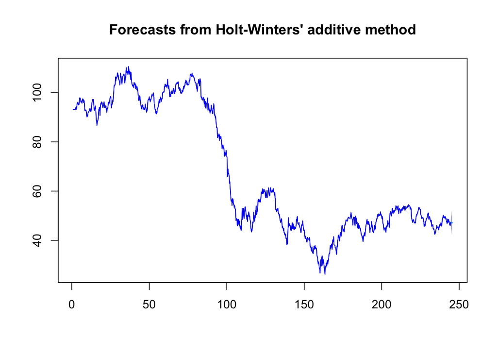

```r
# Make a forecast for the next 12 time periods
forecast <- forecast(hw_model1, h = 5)

# Plot the forecast and the actual data
plot(forecast)
lines(oil_ts, col = "blue")
```

#### **2.Holt-Winters Multiplicative Model**

```r
# Fit a model to the training data
hw_model1 <- hw(oil_ts,seasonal="multiplicative" )
summary(hw_model1)
```

```
##
## Forecast method: Holt-Winters' multiplicative method
##
## Model Information:
## Holt-Winters' multiplicative method
##
## Call:
##  hw(y = oil_ts, seasonal = "multiplicative")
##
##   Smoothing parameters:
##     alpha = 0.892
##     beta  = 0.0455
##     gamma = 1e-04
##
##   Initial states:
##     l = 94.5297
##     b = 1.8436
##     s = 1 1.0009 0.9998 0.9998 0.9995
##
##   sigma:  0.0228
##
##      AIC     AICc      BIC
## 9544.232 9544.414 9595.282
##
## Error measures:
##                       ME     RMSE      MAE         MPE     MAPE      MASE
## Training set -0.03354147 1.226532 0.922521 -0.03333603 1.580296 0.4574254
##                   ACF1
## Training set 0.0516609
##
## Forecasts:
##        Point Forecast    Lo 80    Hi 80    Lo 95    Hi 95
## 244.60       47.15184 45.77392 48.52976 45.04450 49.25919
## 244.80       47.08897 45.20217 48.97577 44.20335 49.97459
## 245.00       47.05494 44.73406 49.37583 43.50545 50.60443
## 245.20       47.05271 44.33365 49.77177 42.89426 51.21116
## 245.40       47.03442 43.93970 50.12914 42.30146 51.76738
## 245.60       47.06965 43.60878 50.53052 41.77670 52.36260
## 245.80       47.00686 43.19565 50.81807 41.17811 52.83560
## 246.00       46.97286 42.81490 51.13083 40.61381 53.33192
## 246.20       46.97060 42.46640 51.47481 40.08201 53.85919
## 246.40       46.95232 42.10508 51.79956 39.53911 54.36553
```

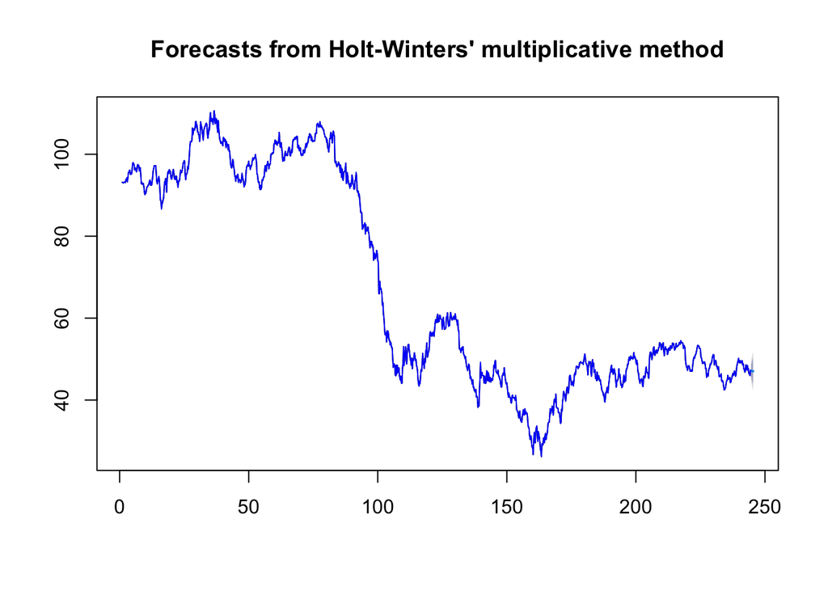

```r
# Make a forecast for the next 12 time periods
forecast <- forecast(hw_model1, h = 5)

# Plot the forecast and the actual data
plot(forecast)
lines(oil_ts, col = "blue")
```

#### **6 & 7 Suitable Models for the Time Series and Checking the adequacy**

#### **ARIMA Model**

ARIMA is a statistical model that is used to forecast time series data. It is relatively easy to understand and implement, and it can be used to forecast a variety of time series data, including those with trend, seasonality, or both.

Advantages:

Easy to understand and implement Can be used to forecast a variety of time series data Relatively accurate, especially for short-term forecasts

Disadvantages:

Can be sensitive to outliers Can be computationally expensive for large datasets May not be as accurate for long-term forecasts

```r
# Convert the data to time series object
oil_ts <- ts(oil_data$dcoilwtico, frequency = 365)
# Fit an ARIMA model to the time series
arima_model <- auto.arima(oil_ts, seasonal = TRUE)
# Print the model summary
summary(arima_model)
```

```
## Series: oil_ts
## ARIMA(0,1,0)
##
## sigma^2 = 1.449:  log likelihood = -1952.37
## AIC=3906.73   AICc=3906.73   BIC=3911.83
##
## Training set error measures:
##                       ME     RMSE       MAE         MPE     MAPE       MASE
## Training set -0.03759184 1.203095 0.8949041 -0.08030733 1.547907 0.03255718
##                     ACF1
## Training set -0.04614975
```

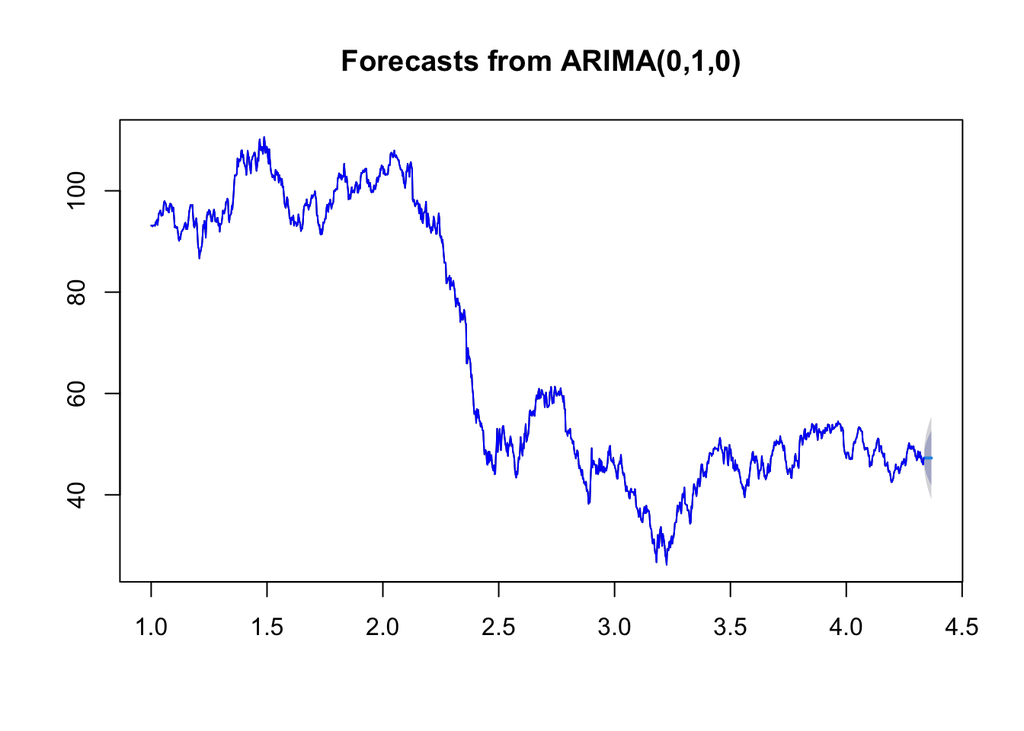

```r
arima_forecast <- forecast(arima_model, h = 12)
plot(arima_forecast)
lines(oil_ts, col = "blue")
```

#### **SARIMA Model**

SARIMA stands for Seasonal Autoregressive Integrated Moving Average. It is a statistical model that is used to forecast time series data that has seasonality. It is a generalization of ARIMA models. It is relatively easy to understand and implement. It can be used to forecast a variety of time series data, including those with trend, seasonality, or both. It is relatively accurate, especially for short-term forecasts. However, it can be sensitive to outliers, computationally expensive for large datasets, and may not be as accurate for long-term forecasts.

```r
# Fit a SARIMA model to the data
sarima_model <- arima(oil_ts, order = c(1, 1, 1), seasonal = list(order = c(1, 0, 0), period = 7))
summary(sarima_model)
```

```
##
## Call:
## arima(x = oil_ts, order = c(1, 1, 1), seasonal = list(order = c(1, 0, 0), period = 7))
##
## Coefficients:
##          ar1      ma1    sar1
##       0.1532  -0.2010  0.0548
## s.e.  0.5390   0.5349  0.0286
##
## sigma^2 estimated as 1.441:  log likelihood = -1949.23,  aic = 3906.46
##
## Training set error measures:
##                       ME     RMSE      MAE         MPE     MAPE     MASE
## Training set -0.03773727 1.199988 0.896225 -0.08046044 1.551265 1.000739
##                       ACF1
## Training set -0.0007080835
```

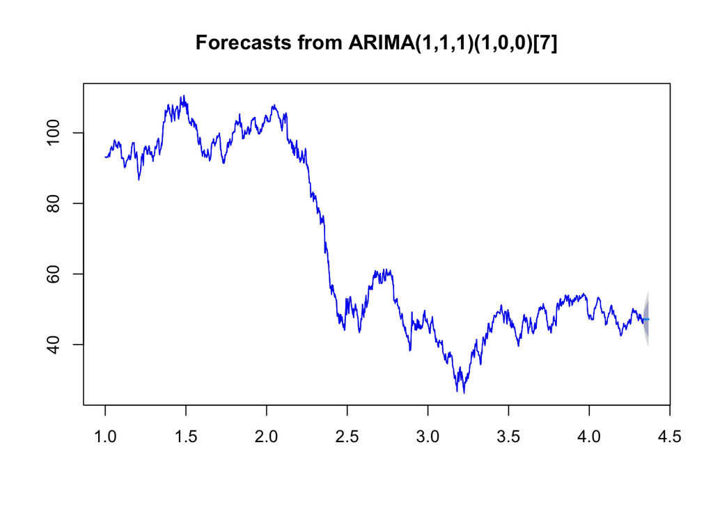

```r
# Make a forecast for the next 12 time periods
sarima_forecast <- forecast(sarima_model, h = 12)
# Plot the forecast and the actual data
plot(sarima_forecast)
lines(oil_ts, col = "blue")
```

#### **8 Comparision between the models**

```r
# Create a data frame
df <- data.frame(
Model = c("ETS(A,N,N)", "ETS(M,N,N)", "ETS(M,M,N)", "Holt-Winters(Additive)", "Holt-Winters(Multiplicative)", "ARIMA", "SARIMA"),
RMSE = c(1.263,1.263,1.262,1.203, 1.226,1.203,1.199),

AIC = c(7381.89,7772.95,7776.70,9124.79,9544.23,3906.73,3906.46),

BIC = c(7396.61,7787.67,7801.24,9175.84,9595.28,3911.83,"-")
)
# Create a table
kable(df, caption = "Comparision Table of Model Performance")
```

Comparision Table of Model Performance

| Model | RMSE | AIC | BIC |
| --- | --- | --- | --- |
| ETS(A,N,N) | 1.263 | 7381.89 | 7396.61 |
| ETS(M,N,N) | 1.263 | 7772.95 | 7787.67 |
| ETS(M,M,N) | 1.262 | 7776.70 | 7801.24 |
| Holt-Winters(Additive) | 1.203 | 9124.79 | 9175.84 |
| Holt-Winters(Multiplicative) | 1.226 | 9544.23 | 9595.28 |
| ARIMA | 1.203 | 3906.73 | 3911.83 |
| SARIMA | 1.199 | 3906.46 | - |

AIC (Akaike Information Criterion) , BIC (Bayesian Information Criterion), RMSE(Root Mean Squared Error) are statistical measures used for model selection in time series analysis. These measures evaluate the tradeoff between the goodness of fit of a model and the complexity of the model.

The AIC value is calculated as 2k - 2ln(L), where k is the number of parameters in the model and ln(L) is the natural logarithm of the likelihood function of the model. The AIC value penalizes models for having more parameters, so a lower AIC value indicates a better model fit.

The BIC value is similar to the AIC, but it includes a larger penalty for models with more parameters. The BIC value is calculated as kln(n) - 2ln(L), where k is the number of parameters in the model, n is the sample size, and ln(L) is the natural logarithm of the likelihood function of the model.

Root Mean Square Error (RMSE) is a measure of the accuracy of forecasts. It is calculated by taking the square root of the average squared error between the actual values and the forecast values. RMSE is a useful measure of accuracy because it is not affected by the scale of the data. It is calculated by RMSE = sqrt(mean( (actual - forecast)^2 ))

In general, a lower AIC or BIC value indicates a better model fit. Therefore, when comparing different models, we choose the model with the lowest AIC or BIC value. However, AIC and BIC should not be used as absolute measures of model fit, and they should be used in combination with other diagnostic tests to ensure that the selected model adequately captures the patterns and dynamics of the time series.

Team Members: Alekhya Monavarthi -50469035 Jayasree Keesari - 50477962 Preethi Abhilasha Vaddi-50483865 Vinitha Vudhayagiri-50478854